# Chapter 2 - Statistical Learning Notes

William Surles

> This document was updated on **2017-06-21**.

## Intro

- Welp. Lets just get through all the code examples.
- I spend too long talking if I start so I’m just gonna do the code and I will come back and add notes if I need to.
- The book has the best notes. : )
- Really, this doc is jut a reference for me to use later

```r
library(stringr)
library(readr)
library(dplyr)
library(ggvis)
library(ISLR)
```

## 2.1 What is Statistical Learning?

## 2.2 Assessing Model Accuracy

## 2.3 Lab: Intro to R

### 2.3.1 Basic Commands

- `c()` combines its inputs into a vector

```r
x <- c(1,3,2,5)
x
```

```
## [1] 1 3 2 5
```

- The `=` symbol works too

```r
y = c(1,4,3)
y
```

```
## [1] 1 4 3
```

- Use `?c` to get help with the `c()` or any function.
- The ‘+’ function will add arrays by index (they must have the same length)
- `?length` to see what the `length` function does. Or any function.

```r
x <- c(1,6,2)
y <- c(1,4,3)
length(x)
```

```
## [1] 3
```

```r
length(y)
```

```
## [1] 3
```

```r
x + y
```

```
## [1]  2 10  5
```

- `ls()` allows you to look at a list of all objects.
- `rm()` is used to delete objects
  - I rarely do this.

```r
ls()
```

```
## [1] "x" "y"
```

```r
rm(x,y)
ls()
```

```
## character(0)
```

- Remove all objects

```r
rm(list=ls())
```

- `matrix()` will create a matrix
  - it needs 3 arguments, the data, the # of rows, and # of columns
  - by default it will create the matrix by columns, left to right

```r
x = matrix(data=c(1,2,3,4), nrow = 2, ncol = 2)
x
```

```
##      [,1] [,2]
## [1,]    1    3
## [2,]    2    4
```

- you don’t need to give the names of the arguments
- you can change all of the default arguments, for example build a matrix by row, rathter than by column
- if you do not assign the matrix to a variable, it will just create it and print it to the screen

```r
x = matrix(c(1,2,3,4), 2, 2, byrow=T)
x
```

```
##      [,1] [,2]
## [1,]    1    2
## [2,]    3    4
```

- `sqrt()` will work on each element of the matrix
- `x^2` will square each element of the matrix

```r
sqrt(x)
```

```
##          [,1]     [,2]
## [1,] 1.000000 1.414214
## [2,] 1.732051 2.000000
```

```r
x^2
```

```
##      [,1] [,2]
## [1,]    1    4
## [2,]    9   16
```

- `rnorm` creates a vetor or random values sampled from the normal distribution
- we get a different sample each time we call the function
- we can change the values of the normal distribution.
- By default the mean is zero and sd is 1
- `cor` will compute the correlation between two vectors

```r
x = rnorm(50)
y = x + rnorm(50, mean=50, sd = .1)
cor(x,y)
```

```
## [1] 0.9931957
```

- `set.seed` will allow you to create the exact same set of random numbers
- this is great for teaching as it lets others get the same set of random numbers in the next functinos

```r
set.seed(1303)
rnorm(50)
```

```
##  [1] -1.1439763145  1.3421293656  2.1853904757  0.5363925179  0.0631929665
##  [6]  0.5022344825 -0.0004167247  0.5658198405 -0.5725226890 -1.1102250073
## [11] -0.0486871234 -0.6956562176  0.8289174803  0.2066528551 -0.2356745091
## [16] -0.5563104914 -0.3647543571  0.8623550343 -0.6307715354  0.3136021252
## [21] -0.9314953177  0.8238676185  0.5233707021  0.7069214120  0.4202043256
## [26] -0.2690521547 -1.5103172999 -0.6902124766 -0.1434719524 -1.0135274099
## [31]  1.5732737361  0.0127465055  0.8726470499  0.4220661905 -0.0188157917
## [36]  2.6157489689 -0.6931401748 -0.2663217810 -0.7206364412  1.3677342065
## [41]  0.2640073322  0.6321868074 -1.3306509858  0.0268888182  1.0406363208
## [46]  1.3120237985 -0.0300020767 -0.2500257125  0.0234144857  1.6598706557
```

- `mean` calculates the mean of a vector of numbers
- `var` calculates the variance of a vector of numbers

```r
set.seed(3)
y = rnorm(100)
mean(y)
```

```
## [1] 0.01103557
```

```r
var(y)
```

```
## [1] 0.7328675
```

```r
# calculate standard deviation
sqrt(var(y))
```

```
## [1] 0.8560768
```

```r
sd(y)
```

```
## [1] 0.8560768
```

### 2.3.2 Graphics

- I will probably use ggvis for all plots rather than base R.
- It is a big improvement on grammar and functionality
- There may be some special R plots I may need to use occasionaly, but it seems to be rare.

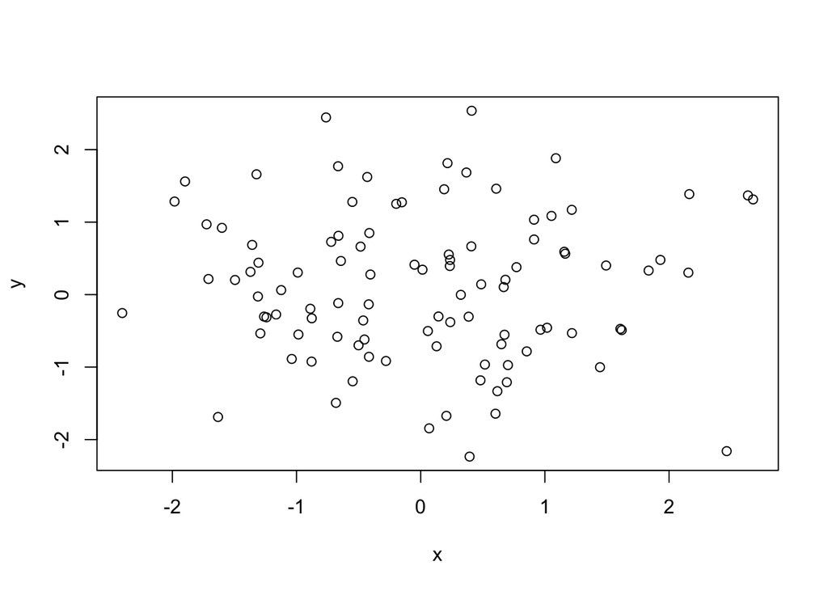

```r
x = rnorm(100)
y = rnorm(100)
plot(x,y)
```

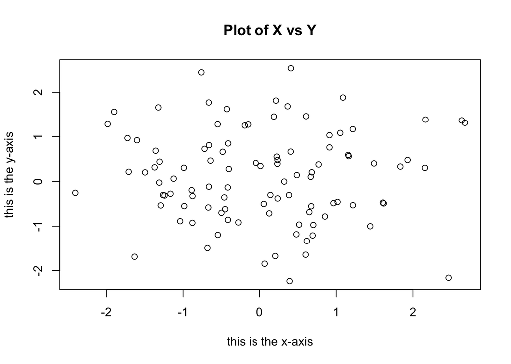

```r
plot(x,y,
     xlab = "this is the x-axis",
     ylab = "this is the y-axis",
     main = "Plot of X vs Y"
     )
```

- similar plot but with ggvis

```r
data.frame(x=rnorm(100), y=rnorm(100)) %>%
  ggvis(~x, ~y) %>%
  layer_points(fill := "blue")
```

[output not shown]

- you can save the output of an R plot
- you can use`pdf()` or `jpeg()`
- `system` lets you can run a system command on the computer
  - here I make a separat folder to put images
  - `dev.off` says we are done creating the plot
- these steps are useful to share the analysis results in an image in an automated way
  - once you have created an analysis and explained it, it may be useful to send updated results on a daily basis to a location.
  - images are nice becasue they can easily be shared in an iframe or flow and be quickly viewed

```r
system("mkdir images")
pdf("images/Figure.pdf")
plot(x,y,col="green")
dev.off()
```

- `?seq` creates a sequence of numbers
- There are many option to control length and step size

```r
x = seq(1:10)
x
```

```
##  [1]  1  2  3  4  5  6  7  8  9 10
```

```r
## This is a shortcut
x = 1:10
x
```

```
##  [1]  1  2  3  4  5  6  7  8  9 10
```

```r
x = seq(-pi, pi, length=20)
x
```

```
##  [1] -3.1415927 -2.8108987 -2.4802047 -2.1495108 -1.8188168 -1.4881228
##  [7] -1.1574289 -0.8267349 -0.4960409 -0.1653470  0.1653470  0.4960409
## [13]  0.8267349  1.1574289  1.4881228  1.8188168  2.1495108  2.4802047
## [19]  2.8108987  3.1415927
```

- `contour` creates a contour plot of 3 dimensional data (like topographic map)
- it takes an x, y, and z argument corresponding to x,y positions
- there are many arguments to fine tune the plot

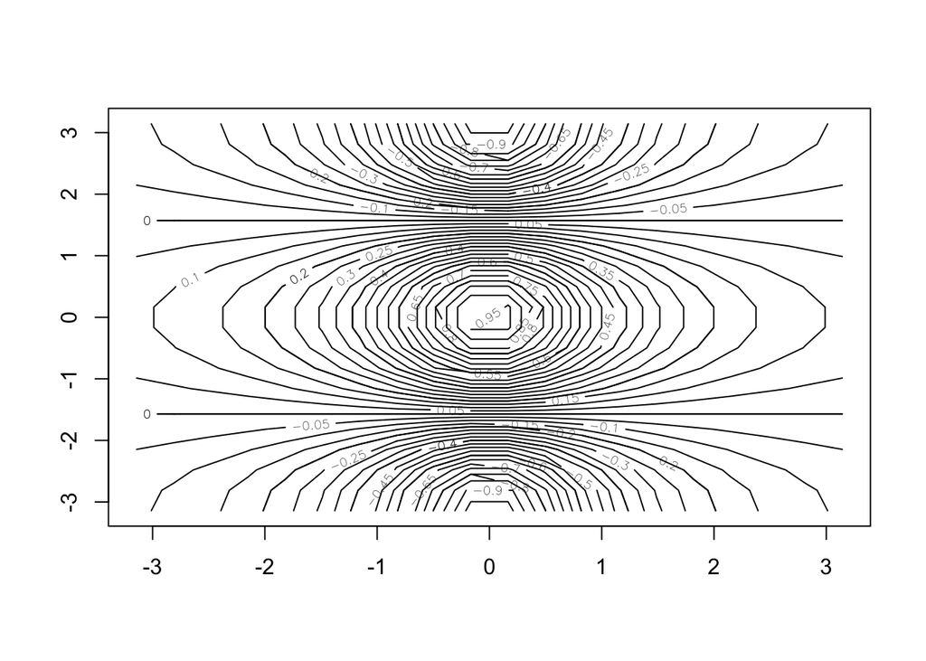

```r
y = x
f = outer(x, y, function(x,y) cos(y)/(1+x^2))
contour(x,y,f)

contour(x,y,f,nlevels=45, add=T)
```

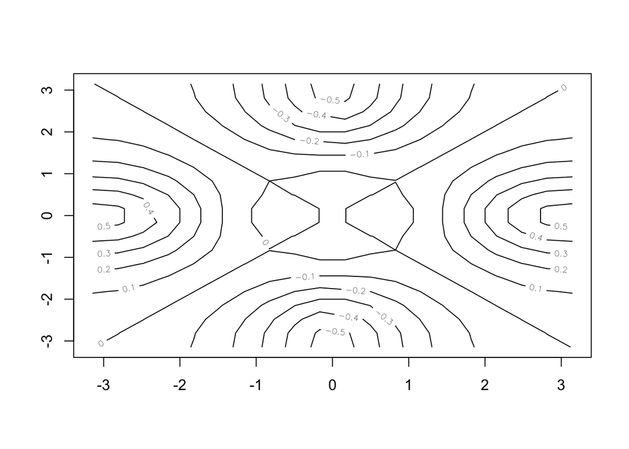

```r
fa = (f-t(f))/2
contour(x,y,fa, nlevels=15)
```

- `image` works like contour, but it uses colors like a heatmap
- `persp` creates a 3D plot. THeta and phi control the viewing angle

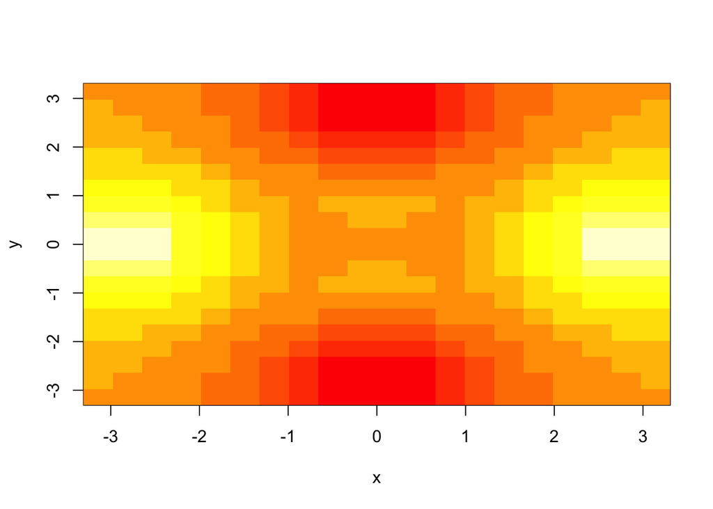

```r
image(x,y,fa)
```

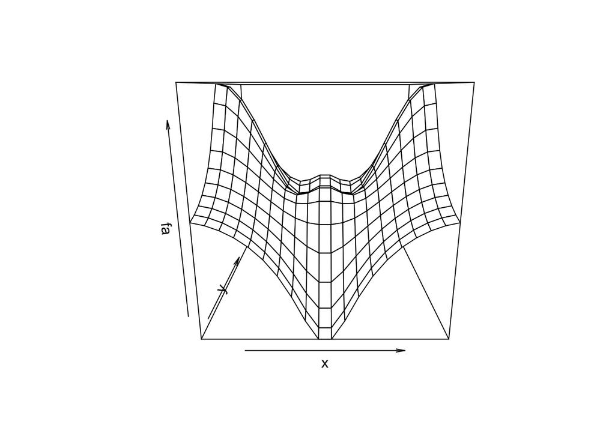

```r
persp(x,y,fa)
```

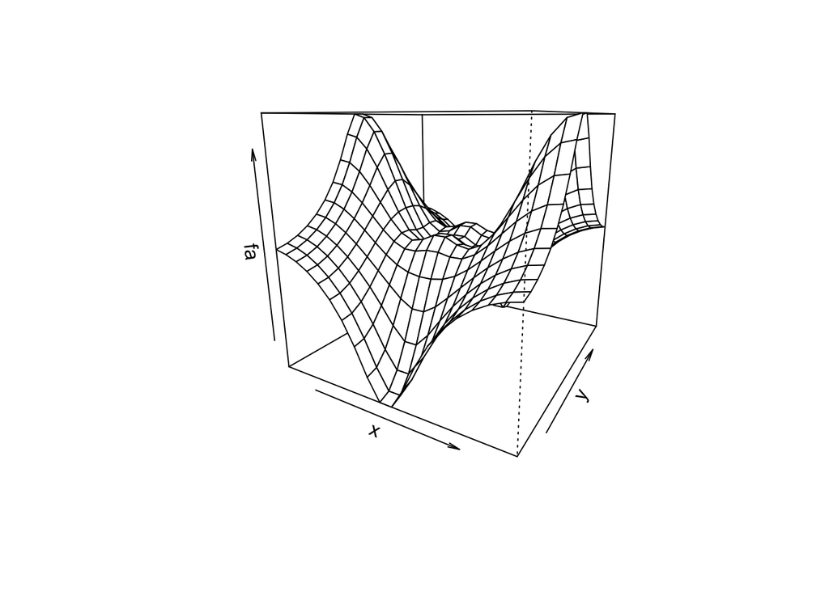

```r
persp(x,y,fa, theta=30)
```

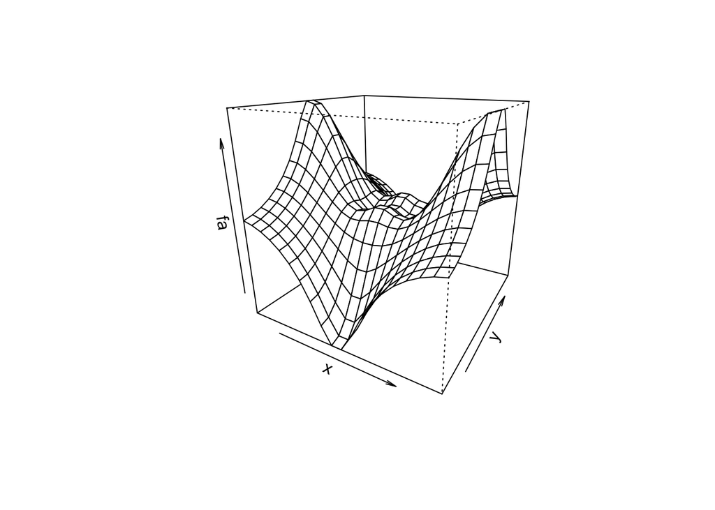

```r
persp(x,y,fa, theta=30, phi=20)
```

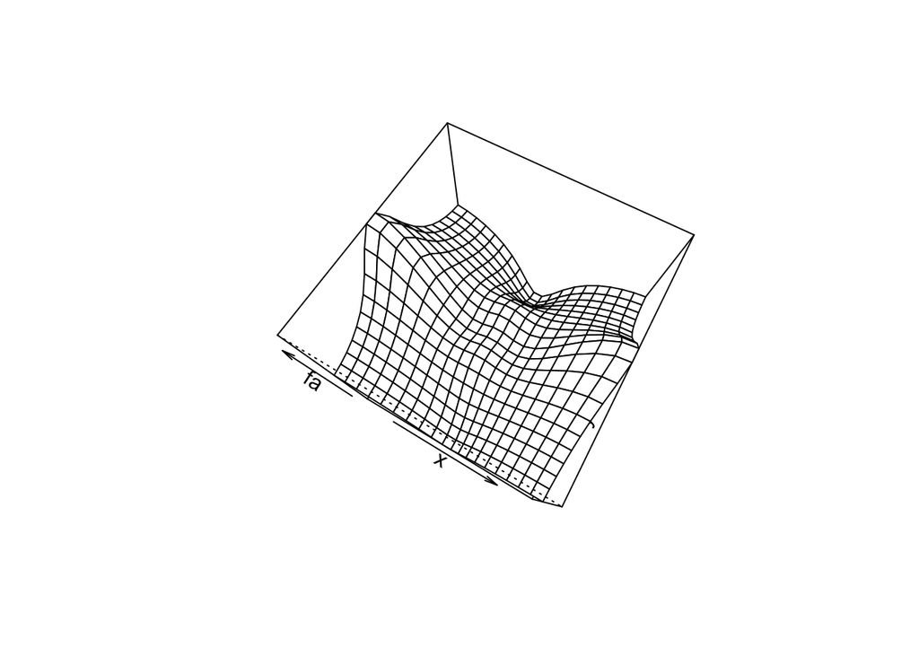

```r
persp(x,y,fa, theta=30, phi=70)
```

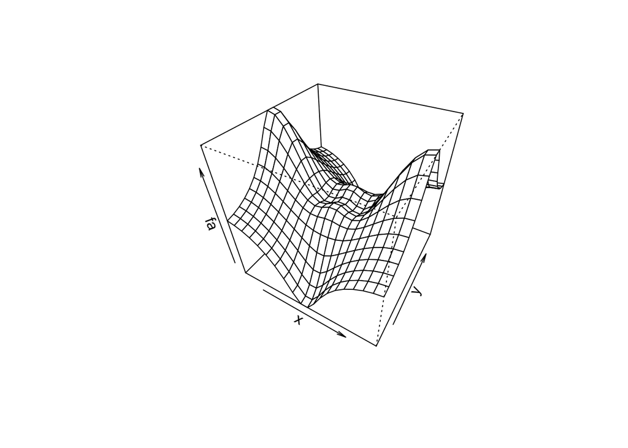

```r
persp(x,y,fa, theta=30, phi=40)
```

### 2.3.3 Indexing Data

- The book just covers matrices
- It works similar for vectors, and dataframes.
- I will mostly be working with dataframes so I added some exampoles here

```r
A = matrix(1:16,4,4)
A
```

```
##      [,1] [,2] [,3] [,4]
## [1,]    1    5    9   13
## [2,]    2    6   10   14
## [3,]    3    7   11   15
## [4,]    4    8   12   16
```

```r
A[2,3]
```

```
## [1] 10
```

```r
A[c(1,3), c(2,4)]
```

```
##      [,1] [,2]
## [1,]    5   13
## [2,]    7   15
```

```r
A[1:3,2:4]
```

```
##      [,1] [,2] [,3]
## [1,]    5    9   13
## [2,]    6   10   14
## [3,]    7   11   15
```

```r
A[1:2,]
```

```
##      [,1] [,2] [,3] [,4]
## [1,]    1    5    9   13
## [2,]    2    6   10   14
```

```r
A[,1:2]
```

```
##      [,1] [,2]
## [1,]    1    5
## [2,]    2    6
## [3,]    3    7
## [4,]    4    8
```

```r
A[1,]
```

```
## [1]  1  5  9 13
```

```r
A[-c(1,3),]
```

```
##      [,1] [,2] [,3] [,4]
## [1,]    2    6   10   14
## [2,]    4    8   12   16
```

```r
dim(A)
```

```
## [1] 4 4
```

- All of these work on a data frame also
- dataframes can also be indexed by column names which reads a little cleaner

```r
df <- data.frame(a=1:4, b=5:8, c=9:12, d=13:16)
df
```

```
##   a b  c  d
## 1 1 5  9 13
## 2 2 6 10 14
## 3 3 7 11 15
## 4 4 8 12 16
```

```r
df[2,3]
```

```
## [1] 10
```

```r
df[c(1,3), c(2,4)]
```

```
##   b  d
## 1 5 13
## 3 7 15
```

```r
df[1:3,2:4]
```

```
##   b  c  d
## 1 5  9 13
## 2 6 10 14
## 3 7 11 15
```

```r
df[1:2,]
```

```
##   a b  c  d
## 1 1 5  9 13
## 2 2 6 10 14
```

```r
df[1:2] ## it defaults to the columns if you do not put in the ,
```

```
##   a b
## 1 1 5
## 2 2 6
## 3 3 7
## 4 4 8
```

```r
df[,1:2]
```

```
##   a b
## 1 1 5
## 2 2 6
## 3 3 7
## 4 4 8
```

```r
df[1,]
```

```
##   a b c  d
## 1 1 5 9 13
```

```r
df[-c(1,3),]
```

```
##   a b  c  d
## 2 2 6 10 14
## 4 4 8 12 16
```

```r
dim(df)
```

```
## [1] 4 4
```

```r
df$a
```

```
## [1] 1 2 3 4
```

```r
df[c('a','b')]
```

```
##   a b
## 1 1 5
## 2 2 6
## 3 3 7
## 4 4 8
```

```r
df[1:2, c('a','b')]
```

```
##   a b
## 1 1 5
## 2 2 6
```

```r
df[c(1,4), c('a','d')]
```

```
##   a  d
## 1 1 13
## 4 4 16
```

### 2.3.4 Loading Data

- I will probably only use readr since it is a newer library that replaces a lot of the code in this section
- Auto is already part of the ISLR library so I don’t need to load it
- `fix` opens a spreadsheet viewer but its really slow
  - This has been replaced by the variable viewer built into R studio
- `read_csv` is the kef function. It has many arguments to customize loading the data, but its defaults do a great job and make life easy. In most cases it does exactly what you would want.

```r
system("mkdir data")
write_csv(Auto, "data/Auto.csv")

df_auto <- read_csv("data/Auto.csv")
str(df_auto)
```

```
## Classes 'tbl_df', 'tbl' and 'data.frame':    392 obs. of  9 variables:
##  $ mpg         : num  18 15 18 16 17 15 14 14 14 15 ...
##  $ cylinders   : int  8 8 8 8 8 8 8 8 8 8 ...
##  $ displacement: num  307 350 318 304 302 429 454 440 455 390 ...
##  $ horsepower  : int  130 165 150 150 140 198 220 215 225 190 ...
##  $ weight      : num  3504 3693 3436 3433 3449 ...
##  $ acceleration: num  12 11.5 11 12 10.5 10 9 8.5 10 8.5 ...
##  $ year        : int  70 70 70 70 70 70 70 70 70 70 ...
##  $ origin      : int  1 1 1 1 1 1 1 1 1 1 ...
##  $ name        : chr  "chevrolet chevelle malibu" "buick skylark 320" "plymouth satellite" "amc rebel sst" ...
##  - attr(*, "spec")=List of 2
##   ..$ cols   :List of 9
##   .. ..$ mpg         : list()
##   .. .. ..- attr(*, "class")= chr  "collector_double" "collector"
##   .. ..$ cylinders   : list()
##   .. .. ..- attr(*, "class")= chr  "collector_integer" "collector"
##   .. ..$ displacement: list()
##   .. .. ..- attr(*, "class")= chr  "collector_double" "collector"
##   .. ..$ horsepower  : list()
##   .. .. ..- attr(*, "class")= chr  "collector_integer" "collector"
##   .. ..$ weight      : list()
##   .. .. ..- attr(*, "class")= chr  "collector_double" "collector"
##   .. ..$ acceleration: list()
##   .. .. ..- attr(*, "class")= chr  "collector_double" "collector"
##   .. ..$ year        : list()
##   .. .. ..- attr(*, "class")= chr  "collector_integer" "collector"
##   .. ..$ origin      : list()
##   .. .. ..- attr(*, "class")= chr  "collector_integer" "collector"
##   .. ..$ name        : list()
##   .. .. ..- attr(*, "class")= chr  "collector_character" "collector"
##   ..$ default: list()
##   .. ..- attr(*, "class")= chr  "collector_guess" "collector"
##   ..- attr(*, "class")= chr "col_spec"
```

```r
glimpse(df_auto)
```

```
## Observations: 392
## Variables: 9
## $ mpg          <dbl> 18, 15, 18, 16, 17, 15, 14, 14, 14, 15, 15, 14, 1...
## $ cylinders    <int> 8, 8, 8, 8, 8, 8, 8, 8, 8, 8, 8, 8, 8, 8, 4, 6, 6...
## $ displacement <dbl> 307, 350, 318, 304, 302, 429, 454, 440, 455, 390,...
## $ horsepower   <int> 130, 165, 150, 150, 140, 198, 220, 215, 225, 190,...
## $ weight       <dbl> 3504, 3693, 3436, 3433, 3449, 4341, 4354, 4312, 4...
## $ acceleration <dbl> 12.0, 11.5, 11.0, 12.0, 10.5, 10.0, 9.0, 8.5, 10....
## $ year         <int> 70, 70, 70, 70, 70, 70, 70, 70, 70, 70, 70, 70, 7...
## $ origin       <int> 1, 1, 1, 1, 1, 1, 1, 1, 1, 1, 1, 1, 1, 1, 3, 1, 1...
## $ name         <chr> "chevrolet chevelle malibu", "buick skylark 320",...
```

```r
head(df_auto)
```

```
## # A tibble: 6 x 9
##     mpg cylinders displacement horsepower weight acceleration  year
##   <dbl>     <int>        <dbl>      <int>  <dbl>        <dbl> <int>
## 1    18         8          307        130   3504         12.0    70
## 2    15         8          350        165   3693         11.5    70
## 3    18         8          318        150   3436         11.0    70
## 4    16         8          304        150   3433         12.0    70
## 5    17         8          302        140   3449         10.5    70
## 6    15         8          429        198   4341         10.0    70
## # ... with 2 more variables: origin <int>, name <chr>
```

```r
names(df_auto)
```

```
## [1] "mpg"          "cylinders"    "displacement" "horsepower"
## [5] "weight"       "acceleration" "year"         "origin"
## [9] "name"
```

### 2.3.5 Aditional Graphical and Numerical Summaries

```r
df_auto %>%
  ggvis(~cylinders, ~mpg) %>%
  layer_points(
    fill := "green",
    fillOpacity := .4
    )
```

[output not shown]